# Chocolate & Chá

Wesley Pinheiro da Silva

2023-03-12

## Descrição

Esses códigos foram escritos no RStudio, realizando a atividade de conclusão do curso de `Análise de dados com programação em R`, para a obtenção do **Certificado Profissional de Análise de Dados**, do *Google*, aplicado pela *Coursera.*

Carregando biblioteca do tidyverse, com todos os pacotes:

```r
library(tidyverse)
```

Neste exercício foram utilizados apenas dois pacotes, o `dplyr` e o `ggplot`.

Carregando base de dados:

```r
chocolates_df <- read.csv("flavors_of_cacao.csv")
```

Essa base de dados foi criado por Rachael Tatman, está em Domínio Público e pode ser acessada através deste [link](https://www.kaggle.com/datasets/rtatman/chocolate-bar-ratings)

## Preparação dos dados

Processo de leitura, limpeza e tratamento dos dados:

```r
#Mudando o nome de uma coluna
chocolates_df %>%
  rename(Company = Company...Maker.if.known.) %>%
  invisible()


#Criando uma Tabela (tribble) com 4 colunas selecionadas
custom_chocolates_df <- chocolates_df %>%
  rename(Company = Company...Maker.if.known.) %>%
  select(Rating, Cocoa.Percent,Company, Company.Location)
  head(custom_chocolates_df)
```

```
##   Rating Cocoa.Percent  Company Company.Location
## 1   3.75           63% A. Morin           France
## 2   2.75           70% A. Morin           France
## 3   3.00           70% A. Morin           France
## 4   3.50           70% A. Morin           France
## 5   3.50           70% A. Morin           France
## 6   2.75           70% A. Morin           France
```

O objetivo desta tabela é limpar os dados, dispensando as colunas que não são úteis para a análise.

Após isso, é importante conhecer qual é a nota máxima nas avaliações dos chocolates.

```r
#Classificação máxima
custom_chocolates_df %>%
  summarize(max(max_rating = Rating))
```

```
##   max(max_rating = Rating)
## 1                        5
```

A maior nota para as avaliações é 5, ou seja, é uma escala que vai de 0 a 5.

Para esta análise será considerado os chocolates que possuem pelo menos 80% de cacau em sua composição, além disso, como um segundo parâmetro de filtro, também será considerado chocolates que tiveram uma avaliação de no mínimo 3,75.

```r
melhores_chocolates_df <- custom_chocolates_df %>%
  filter(Rating >= 3.75 & Cocoa.Percent >=80)
```

Em seguida, salvo como variáveis duas cores que serão usadas na composição dos gráficos.

```r
#Cores
cor_roxa <- rgb(117, 112, 179, maxColorValue = 255)
cor_cinza_claro <- rgb(147, 161, 161, maxColorValue = 255)
```

## Tabelas e Gráficos

Com esses dados levantados, chega a hora de plotar os gráficos, o primeiro gráfico tem como objetivo mostrar quais são os países onde estão as empresas que fabricam chocolate 80% com as avaliações mais altas, a seguir o código em Linguagem R responsável pela criação do gráfico que será mostrado em sequência:

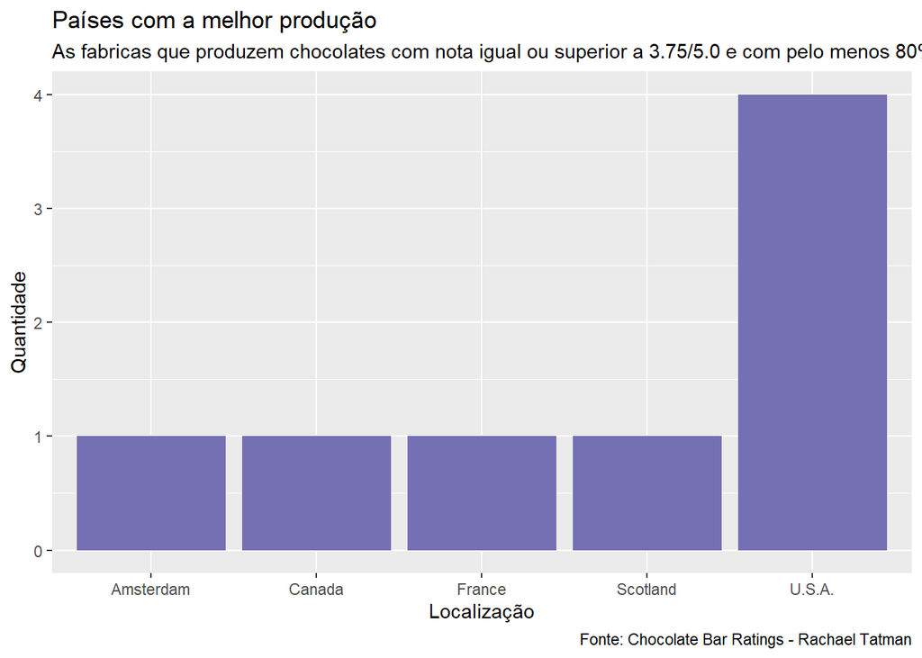

```r
#Locais que produzem as barras de chocolates mais bem avaliadas
ggplot(data = melhores_chocolates_df) +
  geom_bar(mapping = aes(x = Company.Location, fill = cor_roxa)) +
  scale_fill_manual(values = cor_roxa) +
  guides(fill=FALSE) +
  labs(x = "Localização", y = "Quantidade", title="Países com a melhor produção",
       subtitle = "As fabricas que produzem chocolates com nota igual ou superior a 3.75/5.0 e com pelo menos 80% de cacau" ,
       caption = "Fonte: Chocolate Bar Ratings - Rachael Tatman")
```

Dentro dos países que obteram as avaliações mais altas, o próximo código e gráfico busca mostrar quais desses países tem as melhores avaliações em seus chocolates 80%.

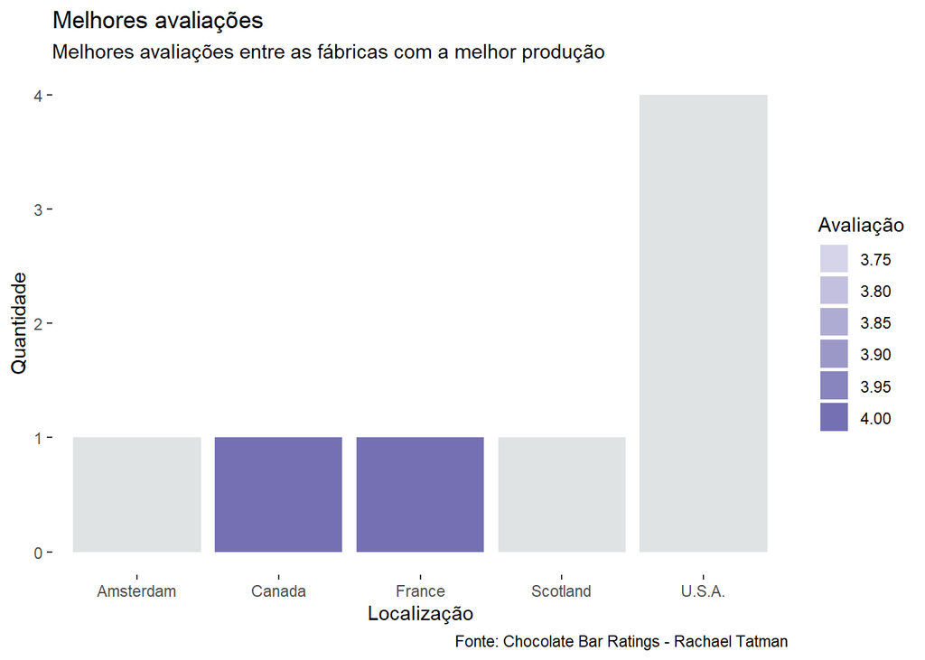

```r
#Lugares com as notas mais altas
  ggplot(data = melhores_chocolates_df) +
    geom_bar(mapping = aes(x = Company.Location, alpha = Rating, fill = Rating)) +
    #Escala personalizada
    scale_fill_gradient(low = cor_cinza_claro, high = cor_roxa) +
    scale_alpha(range = c(0.3, 1)) +
    guides(fill=FALSE, alpha = guide_legend(title = "Avaliação", override.aes = list(fill = cor_roxa, color = "white"))) +
    labs(x = "Localização", y = "Quantidade", title = "Melhores Chocolates", fill = "", alpha = "Avaliação") +
    theme(panel.background = element_rect(fill = "white"),
          legend.key = element_rect(fill = "white", color = "white"),
          legend.text = element_text(color = "black"))+
    #Títuloos e legendas
    labs(title="Melhores avaliações",
         subtitle = "Melhores avaliações entre as fábricas com a melhor produção" ,
         caption = "Fonte: Chocolate Bar Ratings - Rachael Tatman")
```